# Understanding the Mass Incarceration Epidemic

Munir Emam

2022-11-01

## Abstract

mass incarcerations have been a huge problem in the US. Learning and Understanding the details is key to improving this worsening problem. This analysis points out key problems and issues facing prisons around the country.

## Introduction

Mass incarcerations isn’t a phenomenon, it has been happening throughout this country’s history. African Americans have been increasingly been sent to prison throughout our history, as well as other people of color. The mass incarceration epidemic has been effecting prisoners unjustly, as well indirectly towards their family.

The questions that I will be answer in this report are:

- What factors increase your chance of being in prison?
- What race is overincarcerated
- What type of incarcerations make up the Jail population?

## Data Summary

In total their have been 23,207,908 total incarcerations in the US. With black incarcerations making up 7,891,239 incarcerations. African Americans make up 5.442801% but make up 34.00237% of incarcerations. This means that black communities are being over incarcerated.

## Growth of the U.S. Prison Population

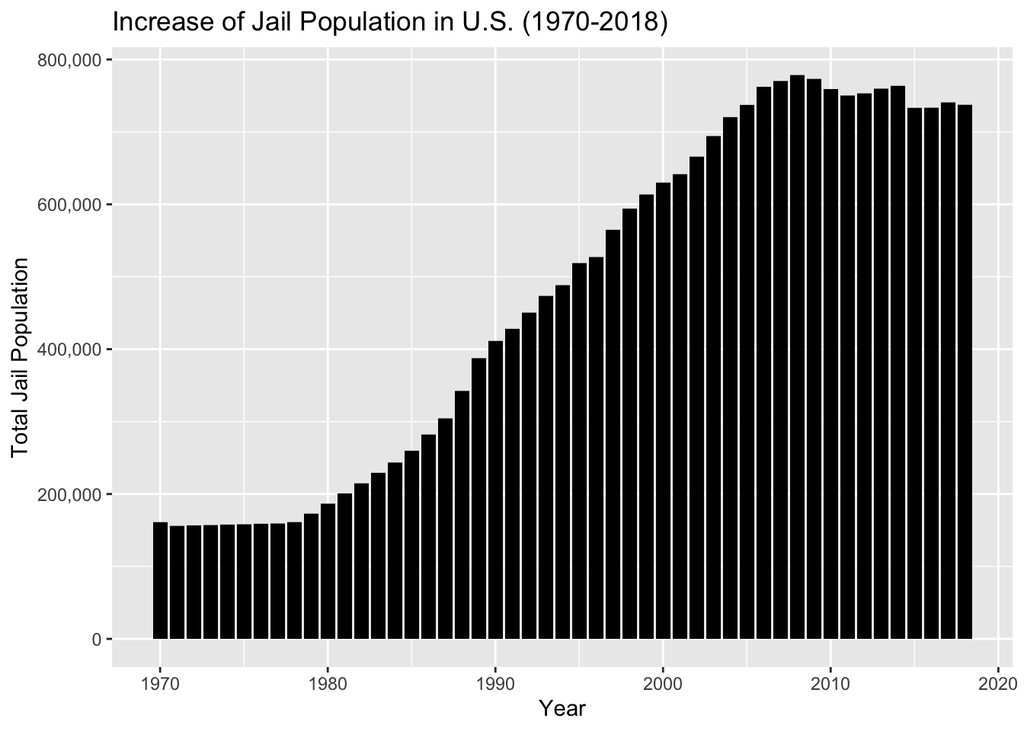

After assessing this charts it seems that incarcerations have been climbing fast since the 1970, and looks like incarcerations have about quadrupled from 1970 to 2018.

## Growth of Prison Population by State

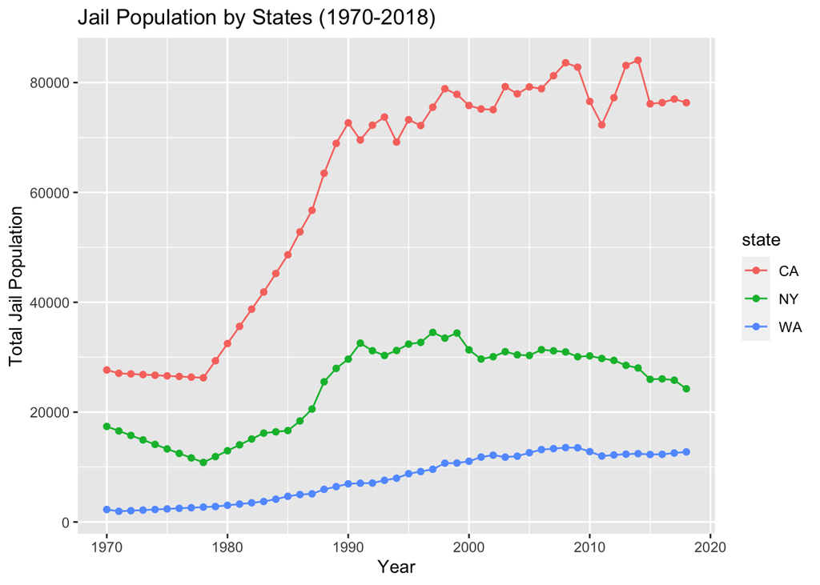

When you assess this chart you can see that California has a big jump of incarcerations between 1980-1990, you can also see that Washington has being increasing their incarcerations, But New York has steadily been decreasing since the mid 1990s.

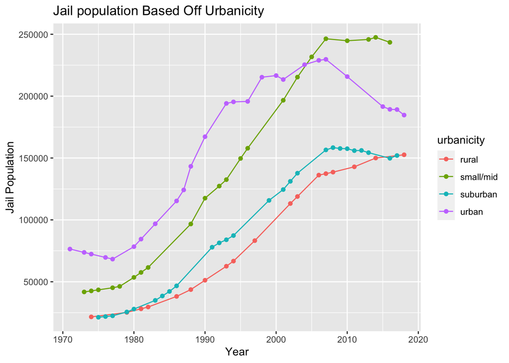

- What types of Incarcerations makeup Jail populations?

It seems that majority of the population is made up of small/mid and urban areas. These means that rural and suburban areas see the least amount of incarcerations, even though major parts of the population live in suburbs and rural areas.

When you assess this chart you can see that urban jail populations have been plummeting, while the other urbanicitys have slowed their climb.

## Jail Population of Blacks

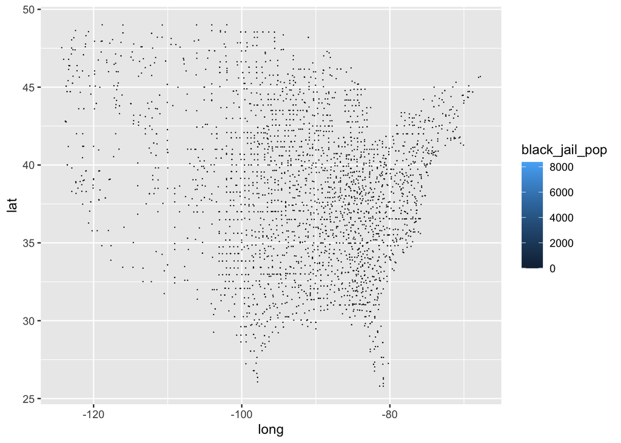

- What race is over incarcerated?